# 🏦 Loan Approval Prediction

## Group 4 | Applied Machine Learning | BUAN 6341

### The University of Texas at Dallas

**Target Variable:**

- `loan_status = 1` → **Approved**
- `loan_status = 0` → **Rejected**

*(Source: Kaggle dataset documentation — taweilo/loan-approval-classification-data)*

**Team:** Akanksha Anand • Annu Choudhary • Vishwajith Jagadeesan • Kundayi Mukucha • Abhidnya Raut

## 0. Install Required Libraries

Run this cell once before anything else.

```python
!pip install scikit-learn pandas numpy matplotlib seaborn imbalanced-learn xgboost lightgbm
```

## 1. Data Loading

Load the dataset and perform an initial inspection.

> **Note:** Place `loan_data.csv` in the same folder as this notebook before running.

```python
import pandas as pd

df = pd.read_csv("loan_data.csv")
print(f"Dataset Shape: {df.shape}")
print(f"\nColumn Names:")
print(df.columns.tolist())
print(f"\nFirst 5 rows:")
df.head()
```

```
Dataset Shape: (45000, 14)

Column Names:
['person_age', 'person_gender', 'person_education', 'person_income', 'person_emp_exp', 'person_home_ownership', 'loan_amnt', 'loan_intent', 'loan_int_rate', 'loan_percent_income', 'cb_person_cred_hist_length', 'credit_score', 'previous_loan_defaults_on_file', 'loan_status']

First 5 rows:
```

|  | person_age | person_gender | person_education | person_income | person_emp_exp | person_home_ownership | loan_amnt | loan_intent | loan_int_rate | loan_percent_income | cb_person_cred_hist_length | credit_score | previous_loan_defaults_on_file | loan_status |
| --- | --- | --- | --- | --- | --- | --- | --- | --- | --- | --- | --- | --- | --- | --- |
| 0 | 22 | female | Master | 71948 | 0 | RENT | 35000 | PERSONAL | 16.02 | 0.49 | 3 | 561 | No | 1 |
| 1 | 21 | female | High School | 12282 | 0 | OWN | 1000 | EDUCATION | 11.14 | 0.08 | 2 | 504 | Yes | 0 |
| 2 | 25 | female | High School | 12438 | 3 | MORTGAGE | 5500 | MEDICAL | 12.87 | 0.44 | 3 | 635 | No | 1 |
| 3 | 23 | female | Bachelor | 79753 | 0 | RENT | 35000 | MEDICAL | 15.23 | 0.44 | 2 | 675 | No | 1 |
| 4 | 24 | male | Master | 66135 | 1 | RENT | 35000 | MEDICAL | 14.27 | 0.53 | 4 | 586 | No | 1 |

```python
# Quick summary of target variable
print("Target Variable — loan_status:")
print(f"  1 = Approved: {sum(df['loan_status']==1):,} ({sum(df['loan_status']==1)/len(df)*100:.1f}%)")
print(f"  0 = Rejected: {sum(df['loan_status']==0):,} ({sum(df['loan_status']==0)/len(df)*100:.1f}%)")
print(f"\nOverall Approval Rate: {df['loan_status'].mean():.2%}")
```

```
Target Variable — loan_status:
  1 = Approved: 10,000 (22.2%)
  0 = Rejected: 35,000 (77.8%)

Overall Approval Rate: 22.22%
```

## 2. Preprocessing

### 2.1 Label Encoding

Binary categorical columns are encoded using Label Encoding.

- `person_gender`: female → 0, male → 1
- `previous_loan_defaults_on_file`: No → 0, Yes → 1

```python
from sklearn.preprocessing import LabelEncoder

le = LabelEncoder()
df["person_gender"] = le.fit_transform(df["person_gender"])
df["previous_loan_defaults_on_file"] = le.fit_transform(df["previous_loan_defaults_on_file"])

print("Label Encoding complete:")
print(df[["person_gender", "previous_loan_defaults_on_file"]].head())
```

```
Label Encoding complete:
   person_gender  previous_loan_defaults_on_file
0              0                               0
1              0                               1
2              0                               0
3              0                               0
4              1                               0
```

### 2.2 One-Hot Encoding

Multi-category columns are one-hot encoded to avoid implying false ordinal relationships between categories.

```python
df = pd.get_dummies(df, columns=["person_education", "person_home_ownership", "loan_intent"], drop_first=False)
df = df.astype({col: int for col in df.select_dtypes(bool).columns})

print(f"Shape after encoding: {df.shape}")
print(f"\nAll columns:")
print(df.columns.tolist())
```

```
Shape after encoding: (45000, 26)

All columns:
['person_age', 'person_gender', 'person_income', 'person_emp_exp', 'loan_amnt', 'loan_int_rate', 'loan_percent_income', 'cb_person_cred_hist_length', 'credit_score', 'previous_loan_defaults_on_file', 'loan_status', 'person_education_Associate', 'person_education_Bachelor', 'person_education_Doctorat…
```

### 2.3 Train/Test Split

Stratified 80/20 split — `stratify=y` ensures both sets preserve the 77.8/22.2 class ratio.

```python
from sklearn.model_selection import train_test_split

X = df.drop("loan_status", axis=1)
y = df["loan_status"]

X_train, X_test, y_train, y_test = train_test_split(
    X, y, test_size=0.2, random_state=42, stratify=y
)

print(f"X_train: {X_train.shape}")
print(f"X_test:  {X_test.shape}")
print(f"Train approval rate: {y_train.mean():.2%}")
print(f"Test approval rate:  {y_test.mean():.2%}")
```

```
X_train: (36000, 25)
X_test:  (9000, 25)
Train approval rate: 22.22%
Test approval rate:  22.22%
```

### 2.4 SMOTE — Handling Class Imbalance

SMOTE is applied **only to the training set** to oversample the minority (Approved) class to a 60/40 ratio. The test set is never touched — it remains a faithful sample of reality.

- Class 0 = Rejected (majority)
- Class 1 = Approved (minority — oversampled)

```python
from imblearn.over_sampling import SMOTE

smote = SMOTE(sampling_strategy=0.67, random_state=42)
X_train_res, y_train_res = smote.fit_resample(X_train, y_train)

print(f"Before SMOTE — Rejected (0): {sum(y_train==0):,}  Approved (1): {sum(y_train==1):,}")
print(f"After SMOTE  — Rejected (0): {sum(y_train_res==0):,}  Approved (1): {sum(y_train_res==1):,}")
print(f"New approval rate in training set: {y_train_res.mean():.2%}")
```

```
Before SMOTE — Rejected (0): 28,000  Approved (1): 8,000
After SMOTE  — Rejected (0): 28,000  Approved (1): 18,760
New approval rate in training set: 40.12%
```

### 2.5 Feature Scaling

StandardScaler is fitted on training data only and applied to both train and test sets. This prevents data leakage — test set statistics never influence the scaler.

```python
from sklearn.preprocessing import StandardScaler

scaler = StandardScaler()
X_train_scaled = scaler.fit_transform(X_train_res)
X_test_scaled  = scaler.transform(X_test)

print("Scaling complete. Verification (mean ≈ 0, std ≈ 1):")
import pandas as pd
pd.DataFrame(X_train_scaled).describe().round(2)
```

```
Scaling complete. Verification (mean ≈ 0, std ≈ 1):
```

|  | 0 | 1 | 2 | 3 | 4 | 5 | 6 | 7 | 8 | 9 | ... | 15 | 16 | 17 | 18 | 19 | 20 | 21 | 22 | 23 | 24 |
| --- | --- | --- | --- | --- | --- | --- | --- | --- | --- | --- | --- | --- | --- | --- | --- | --- | --- | --- | --- | --- | --- |
| count | 46760.00 | 46760.00 | 46760.00 | 46760.00 | 46760.00 | 46760.00 | 46760.00 | 46760.00 | 46760.00 | 46760.00 | ... | 46760.00 | 46760.00 | 46760.00 | 46760.00 | 46760.00 | 46760.00 | 46760.00 | 46760.00 | 46760.00 | 46760.00 |
| mean | -0.00 | -0.00 | 0.00 | -0.00 | -0.00 | 0.00 | -0.00 | 0.00 | -0.00 | -0.00 | ... | -0.00 | 0.00 | -0.00 | -0.00 | -0.00 | 0.00 | 0.00 | -0.00 | 0.00 | 0.00 |
| std | 1.00 | 1.00 | 1.00 | 1.00 | 1.00 | 1.00 | 1.00 | 1.00 | 1.00 | 1.00 | ... | 1.00 | 1.00 | 1.00 | 1.00 | 1.00 | 1.00 | 1.00 | 1.00 | 1.00 | 1.00 |
| min | -1.31 | -0.98 | -0.87 | -0.90 | -1.44 | -2.00 | -1.62 | -1.00 | -5.02 | -0.80 | ... | -0.71 | -0.05 | -0.23 | -1.10 | -0.40 | -0.44 | -0.31 | -0.45 | -0.40 | -0.40 |
| 25% | -0.62 | -0.98 | -0.42 | -0.73 | -0.75 | -0.70 | -0.78 | -0.73 | -0.61 | -0.80 | ... | -0.71 | -0.05 | -0.23 | -1.10 | -0.40 | -0.44 | -0.31 | -0.45 | -0.40 | -0.40 |
| 50% | -0.28 | -0.98 | -0.16 | -0.21 | -0.26 | -0.08 | -0.25 | -0.46 | 0.13 | -0.80 | ... | -0.71 | -0.05 | -0.23 | 0.91 | -0.40 | -0.44 | -0.31 | -0.45 | -0.40 | -0.40 |
| 75% | 0.41 | 1.02 | 0.20 | 0.47 | 0.50 | 0.69 | 0.59 | 0.61 | 0.73 | 1.25 | ... | 1.40 | -0.05 | -0.23 | 0.91 | -0.40 | -0.44 | -0.31 | -0.45 | -0.40 | -0.40 |
| max | 20.05 | 1.02 | 92.00 | 20.60 | 3.86 | 2.84 | 5.31 | 6.49 | 4.50 | 1.25 | ... | 1.40 | 21.49 | 4.28 | 0.91 | 2.48 | 2.26 | 3.21 | 2.24 | 2.51 | 2.49 |

8 rows × 25 columns

## 3. Exploratory Data Analysis (EDA)

> **Reminder:** `loan_status` mean = approval rate (proportion of applications approved).

```python
%matplotlib inline
import matplotlib.pyplot as plt
import seaborn as sns

df_eda = pd.read_csv("loan_data.csv")
```

### 3.1 Target Class Distribution

Visualizing the class imbalance — 77.8% rejected vs 22.2% approved.

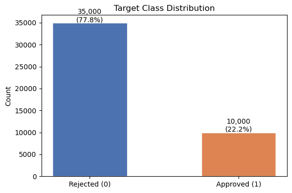

```python
fig, ax = plt.subplots(figsize=(6, 4))

counts = df["loan_status"].value_counts()
ax.bar(["Rejected (0)", "Approved (1)"], counts.values,
       color=["#4C72B0", "#DD8452"], edgecolor="white", width=0.5)

for bar, val in zip(ax.patches, counts.values):
    ax.text(bar.get_x() + bar.get_width()/2, bar.get_height() + 200,
            f"{val:,}\n({val/len(df)*100:.1f}%)", ha="center", fontsize=10)

ax.set_title("Target Class Distribution")
ax.set_ylabel("Count")
plt.tight_layout()
plt.show()
```

### 3.2 Approval Rate by Loan Intent

Which loan purpose has the highest approval rate?

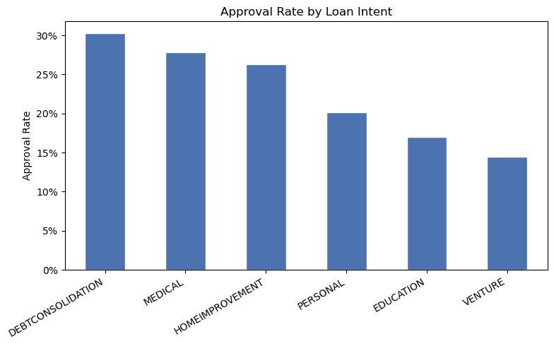

```python
fig, ax = plt.subplots(figsize=(8, 5))

intent_approval = df_eda.groupby("loan_intent")["loan_status"].mean().sort_values(ascending=False)
intent_approval.plot(kind="bar", ax=ax, color="#4C72B0", edgecolor="white")

ax.set_title("Approval Rate by Loan Intent")
ax.set_ylabel("Approval Rate")
ax.set_xlabel("")
ax.set_xticklabels(ax.get_xticklabels(), rotation=30, ha="right")
ax.yaxis.set_major_formatter(plt.FuncFormatter(lambda y, _: f"{y:.0%}"))

plt.tight_layout()
plt.show()
```

### 3.3 Approval Rate by Education Level

Does education level affect loan approval?

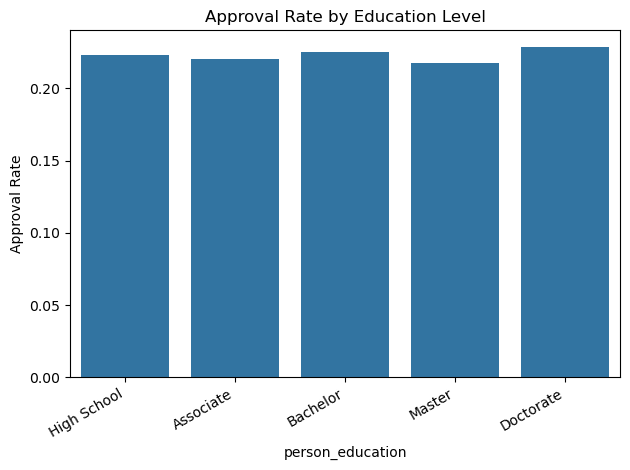

```python
edu_order = ["High School", "Associate", "Bachelor", "Master", "Doctorate"]
edu_approval = df_eda.groupby("person_education")["loan_status"].mean().reindex(edu_order)

sns.barplot(x=edu_approval.index, y=edu_approval.values)
plt.title("Approval Rate by Education Level")
plt.ylabel("Approval Rate")
plt.xticks(rotation=30, ha="right")
plt.tight_layout()
plt.show()
```

### 3.4 Credit Score vs Loan Amount by Approval Status

Do approved and rejected applicants have different credit score profiles?

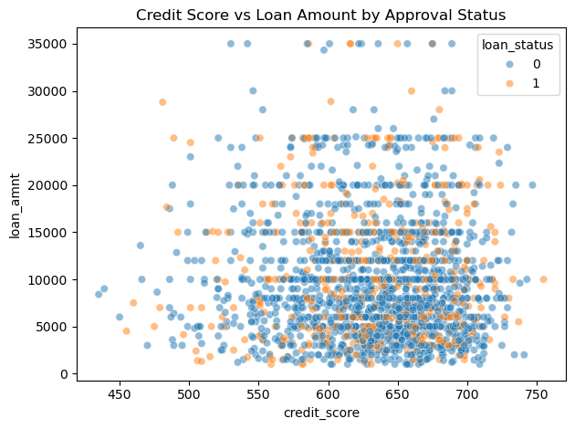

```python
sample = df_eda.sample(2000, random_state=42)
sns.scatterplot(data=sample, x="credit_score", y="loan_amnt",
                hue="loan_status", alpha=0.5)
plt.title("Credit Score vs Loan Amount by Approval Status")
plt.tight_layout()
plt.show()
```

### 3.5 Feature Correlation Heatmap

Which features are most correlated with loan approval status?

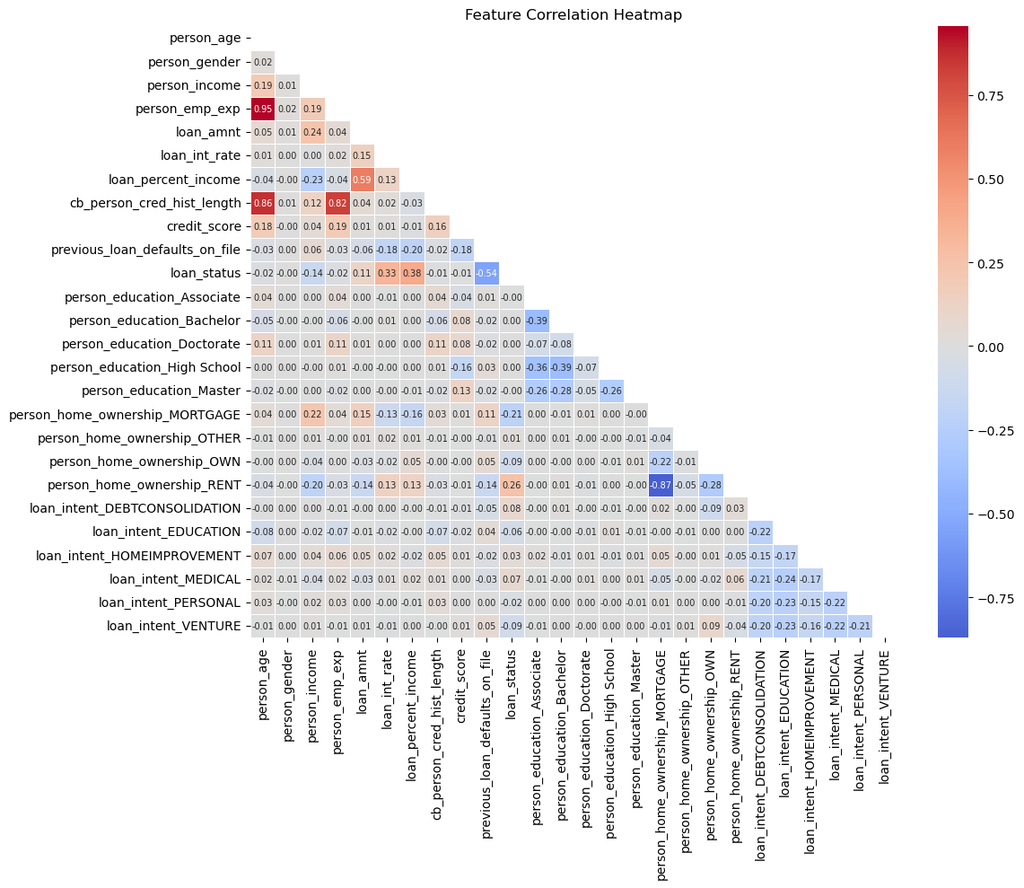

```python
import numpy as np

fig, ax = plt.subplots(figsize=(12, 10))

corr = df.corr()
mask = np.triu(np.ones_like(corr, dtype=bool))
sns.heatmap(corr, mask=mask, ax=ax, annot=True, fmt=".2f",
            cmap="coolwarm", center=0, linewidths=0.5,
            annot_kws={"size": 7})

ax.set_title("Feature Correlation Heatmap")
plt.tight_layout()
plt.show()
```

### 3.6 Approval Rate by Home Ownership

Do renters vs homeowners have different approval rates?

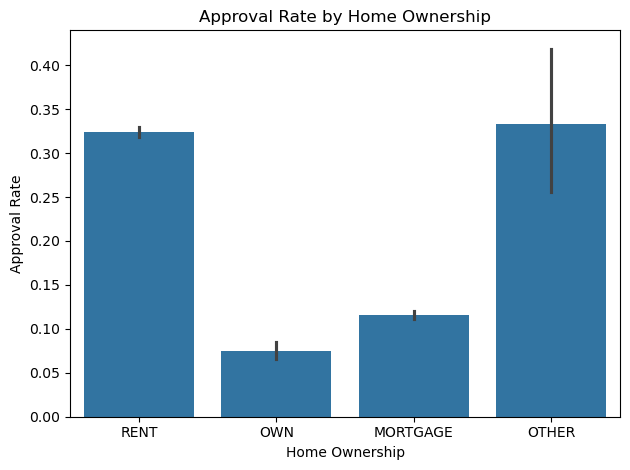

```python
sns.barplot(x=df_eda["person_home_ownership"], y=df_eda["loan_status"])
plt.title("Approval Rate by Home Ownership")
plt.ylabel("Approval Rate")
plt.xlabel("Home Ownership")
plt.tight_layout()
plt.show()
```

## 4. Model Building

All models follow the same consistent evaluation format:

1. Train on `X_train_scaled` + `y_train_res` (SMOTE-balanced, scaled)
2. Predict on both train and test sets
3. Classification report (precision, recall, F1)
4. Confusion matrix
5. Overfitting check (train vs test accuracy)

> **Target:** Class 1 = Approved | Class 0 = Rejected

```python
from sklearn.metrics import classification_report, confusion_matrix, accuracy_score, roc_auc_score
```

### 4.1 Logistic Regression

**Baseline model** — establishes the performance floor. Answers: *Is approval risk linearly separable?*

```python
from sklearn.linear_model import LogisticRegression

# Train
lr = LogisticRegression(max_iter=1000, random_state=42)
lr.fit(X_train_scaled, y_train_res)

# Predict
y_pred_lr       = lr.predict(X_test_scaled)
y_pred_lr_train = lr.predict(X_train_scaled)

# Training Set Report
print("Logistic Regression - Training Set Results")
print("="*40)
print(classification_report(y_train_res, y_pred_lr_train))

# Test Set Report
print("Logistic Regression - Test Set Results")
print("="*40)
print(classification_report(y_test, y_pred_lr))

# Confusion Matrix
print("Confusion Matrix (Test Set):")
print(confusion_matrix(y_test, y_pred_lr))

# Overfitting Check
print(f"\nTrain Accuracy: {accuracy_score(y_train_res, y_pred_lr_train):.2%}")
print(f"Test Accuracy:  {accuracy_score(y_test, y_pred_lr):.2%}")
print(f"Difference:     {abs(accuracy_score(y_train_res, y_pred_lr_train) - accuracy_score(y_test, y_pred_lr)):.2%}")
```

```
Logistic Regression - Training Set Results
========================================
              precision    recall  f1-score   support

           0       0.93      0.93      0.93     28000
           1       0.90      0.89      0.90     18760

    accuracy                           0.92     46760
   macro avg       0.91      0.91      0.91     46760
weighted avg       0.92      0.92      0.92     46760

Logistic Regression - Test Set Results
========================================
              precision    recall  f1-score   support

           0       0.93      0.94      0.94      7000
           1       0.78      0.76      0.77      2000

    accuracy                           0.90      9000
   macro avg       0.86      0.85      0.85      9000
weighted avg       0.90      0.90      0.90      9000

Confusion Matrix (Test Set):
[[6571  429]
 [ 473 1527]]

Train Accuracy: 91.68%
Test Accuracy:  89.98%
Difference:     1.70%
```

### 4.2 Decision Tree (with GridSearchCV)

Captures non-linear feature interactions. Answers: *What does the actual approval boundary look like?*

GridSearchCV across 72 combinations to find optimal hyperparameters.

```python
from sklearn.tree import DecisionTreeClassifier
from sklearn.model_selection import GridSearchCV

param_grid = {
    "max_depth":        [4, 6, 8, 10],
    "min_samples_split":[2, 5, 10],
    "min_samples_leaf": [1, 2, 4],
    "criterion":        ["gini", "entropy"]
}

dt_grid = GridSearchCV(
    DecisionTreeClassifier(random_state=42),
    param_grid, cv=5, scoring="f1", n_jobs=-1, verbose=1
)
dt_grid.fit(X_train_scaled, y_train_res)

print(f"Best Parameters: {dt_grid.best_params_}")
print(f"Best CV F1 Score: {dt_grid.best_score_:.3f}")

dt = dt_grid.best_estimator_
y_pred_dt       = dt.predict(X_test_scaled)
y_pred_dt_train = dt.predict(X_train_scaled)

print("\nDecision Tree - Training Set Results")
print("="*40)
print(classification_report(y_train_res, y_pred_dt_train))

print("Decision Tree - Test Set Results")
print("="*40)
print(classification_report(y_test, y_pred_dt))

print("Confusion Matrix (Test Set):")
print(confusion_matrix(y_test, y_pred_dt))

print(f"\nTrain Accuracy: {accuracy_score(y_train_res, y_pred_dt_train):.2%}")
print(f"Test Accuracy:  {accuracy_score(y_test, y_pred_dt):.2%}")
print(f"Difference:     {abs(accuracy_score(y_train_res, y_pred_dt_train) - accuracy_score(y_test, y_pred_dt)):.2%}")
```

```
Fitting 5 folds for each of 72 candidates, totalling 360 fits
Best Parameters: {'criterion': 'gini', 'max_depth': 10, 'min_samples_leaf': 1, 'min_samples_split': 5}
Best CV F1 Score: 0.881

Decision Tree - Training Set Results
========================================
              precision    recall  f1-score   support

           0       0.93      0.95      0.94     28000
           1       0.92      0.89      0.90     18760

    accuracy                           0.92     46760
   macro avg       0.92      0.92      0.92     46760
weighted avg       0.92      0.92      0.92     46760

Decision Tree - Test Set Results
========================================
              precision    recall  f1-score   support

           0       0.94      0.93      0.94      7000
           1       0.77      0.80      0.78      2000

    accuracy                           0.90      9000
   macro avg       0.86      0.86      0.86      9000
weighted avg       0.90      0.90      0.90      9000

Confusion Matrix (Test Set):
[[6531  469]
 [ 409 1591]]

Train Accuracy: 92.43%
Test Accuracy:  90.24%
Difference:     2.18%
```

### 4.3 Random Forest (with GridSearchCV)

Ensemble of 100+ Decision Trees using bagging. Answers: *Can aggregation produce a more reliable approval boundary?*

```python
from sklearn.ensemble import RandomForestClassifier

param_grid_rf = {
    "n_estimators":     [100, 200, 300],
    "max_depth":        [6, 8, 10],
    "min_samples_split":[2, 5],
    "min_samples_leaf": [1, 2]
}

rf_grid = GridSearchCV(
    RandomForestClassifier(random_state=42),
    param_grid_rf, cv=5, scoring="f1", n_jobs=-1, verbose=1
)
rf_grid.fit(X_train_scaled, y_train_res)

print(f"Best Parameters: {rf_grid.best_params_}")
print(f"Best CV F1 Score: {rf_grid.best_score_:.3f}")

rf = rf_grid.best_estimator_
y_pred_rf       = rf.predict(X_test_scaled)
y_pred_rf_train = rf.predict(X_train_scaled)

print("\nRandom Forest - Training Set Results")
print("="*40)
print(classification_report(y_train_res, y_pred_rf_train))

print("Random Forest - Test Set Results")
print("="*40)
print(classification_report(y_test, y_pred_rf))

print("Confusion Matrix (Test Set):")
print(confusion_matrix(y_test, y_pred_rf))

print(f"\nTrain Accuracy: {accuracy_score(y_train_res, y_pred_rf_train):.2%}")
print(f"Test Accuracy:  {accuracy_score(y_test, y_pred_rf):.2%}")
print(f"Difference:     {abs(accuracy_score(y_train_res, y_pred_rf_train) - accuracy_score(y_test, y_pred_rf)):.2%}")
```

```
Fitting 5 folds for each of 36 candidates, totalling 180 fits
Best Parameters: {'max_depth': 10, 'min_samples_leaf': 1, 'min_samples_split': 5, 'n_estimators': 300}
Best CV F1 Score: 0.901

Random Forest - Training Set Results
========================================
              precision    recall  f1-score   support

           0       0.94      0.96      0.95     28000
           1       0.93      0.91      0.92     18760

    accuracy                           0.94     46760
   macro avg       0.94      0.93      0.93     46760
weighted avg       0.94      0.94      0.94     46760

Random Forest - Test Set Results
========================================
              precision    recall  f1-score   support

           0       0.95      0.95      0.95      7000
           1       0.82      0.81      0.82      2000

    accuracy                           0.92      9000
   macro avg       0.88      0.88      0.88      9000
weighted avg       0.92      0.92      0.92      9000

Confusion Matrix (Test Set):
[[6652  348]
 [ 384 1616]]

Train Accuracy: 93.76%
Test Accuracy:  91.87%
Difference:     1.89%
```

### 4.4 XGBoost — Original

Industry standard gradient boosting. Sequential error correction. GridSearchCV across 54 combinations.

```python
from xgboost import XGBClassifier

param_grid_xgb = {
    "n_estimators": [100, 200, 300],
    "max_depth":    [4, 6, 8],
    "learning_rate":[0.01, 0.1, 0.2],
    "subsample":    [0.8, 1.0]
}

xgb_grid = GridSearchCV(
    XGBClassifier(random_state=42, eval_metric="logloss", n_jobs=-1),
    param_grid_xgb, cv=5, scoring="f1", n_jobs=-1, verbose=1
)
xgb_grid.fit(X_train_scaled, y_train_res)

print(f"Best Parameters: {xgb_grid.best_params_}")
print(f"Best CV F1 Score: {xgb_grid.best_score_:.3f}")

xgb = xgb_grid.best_estimator_
y_pred_xgb       = xgb.predict(X_test_scaled)
y_pred_xgb_train = xgb.predict(X_train_scaled)

print("\nXGBoost - Training Set Results")
print("="*40)
print(classification_report(y_train_res, y_pred_xgb_train))

print("XGBoost - Test Set Results")
print("="*40)
print(classification_report(y_test, y_pred_xgb))

print("Confusion Matrix (Test Set):")
print(confusion_matrix(y_test, y_pred_xgb))

print(f"\nTrain Accuracy: {accuracy_score(y_train_res, y_pred_xgb_train):.2%}")
print(f"Test Accuracy:  {accuracy_score(y_test, y_pred_xgb):.2%}")
print(f"Difference:     {abs(accuracy_score(y_train_res, y_pred_xgb_train) - accuracy_score(y_test, y_pred_xgb)):.2%}")
print("\n⚠ Note: Check overfitting gap — if > 5% regularization is needed")
```

```
Fitting 5 folds for each of 54 candidates, totalling 270 fits
Best Parameters: {'learning_rate': 0.2, 'max_depth': 8, 'n_estimators': 300, 'subsample': 1.0}
Best CV F1 Score: 0.925

XGBoost - Training Set Results
========================================
              precision    recall  f1-score   support

           0       1.00      1.00      1.00     28000
           1       1.00      1.00      1.00     18760

    accuracy                           1.00     46760
   macro avg       1.00      1.00      1.00     46760
weighted avg       1.00      1.00      1.00     46760

XGBoost - Test Set Results
========================================
              precision    recall  f1-score   support

           0       0.95      0.97      0.96      7000
           1       0.88      0.83      0.85      2000

    accuracy                           0.94      9000
   macro avg       0.91      0.90      0.91      9000
weighted avg       0.94      0.94      0.94      9000

Confusion Matrix (Test Set):
[[6764  236]
 [ 339 1661]]

Train Accuracy: 99.98%
Test Accuracy:  93.61%
Difference:     6.37%

⚠ Note: Check overfitting gap — if > 5% regularization is needed
```

### 4.5 XGBoost — Regularized

Adding `reg_lambda` and `min_child_weight` to reduce overfitting detected in the original XGBoost. GridSearchCV across 144 combinations.

```python
param_grid_xgb2 = {
    "n_estimators":     [100, 200, 300],
    "max_depth":        [4, 6],
    "learning_rate":    [0.01, 0.1],
    "subsample":        [0.8, 1.0],
    "reg_lambda":       [1, 5, 10],
    "min_child_weight": [1, 5]
}

xgb_grid2 = GridSearchCV(
    XGBClassifier(random_state=42, eval_metric="logloss", n_jobs=-1),
    param_grid_xgb2, cv=5, scoring="f1", n_jobs=-1, verbose=1
)
xgb_grid2.fit(X_train_scaled, y_train_res)

print(f"Best Parameters: {xgb_grid2.best_params_}")
print(f"Best CV F1 Score: {xgb_grid2.best_score_:.3f}")

xgb2 = xgb_grid2.best_estimator_
y_pred_xgb2       = xgb2.predict(X_test_scaled)
y_pred_xgb2_train = xgb2.predict(X_train_scaled)

print("\nXGBoost Regularized - Training Set Results")
print("="*40)
print(classification_report(y_train_res, y_pred_xgb2_train))

print("XGBoost Regularized - Test Set Results")
print("="*40)
print(classification_report(y_test, y_pred_xgb2))

print("Confusion Matrix (Test Set):")
print(confusion_matrix(y_test, y_pred_xgb2))

print(f"\nTrain Accuracy: {accuracy_score(y_train_res, y_pred_xgb2_train):.2%}")
print(f"Test Accuracy:  {accuracy_score(y_test, y_pred_xgb2):.2%}")
print(f"Difference:     {abs(accuracy_score(y_train_res, y_pred_xgb2_train) - accuracy_score(y_test, y_pred_xgb2)):.2%}")
```

```
Fitting 5 folds for each of 144 candidates, totalling 720 fits
Best Parameters: {'learning_rate': 0.1, 'max_depth': 6, 'min_child_weight': 1, 'n_estimators': 300, 'reg_lambda': 1, 'subsample': 0.8}
Best CV F1 Score: 0.923

XGBoost Regularized - Training Set Results
========================================
              precision    recall  f1-score   support

           0       0.97      0.99      0.98     28000
           1       0.98      0.96      0.97     18760

    accuracy                           0.98     46760
   macro avg       0.98      0.97      0.98     46760
weighted avg       0.98      0.98      0.98     46760

XGBoost Regularized - Test Set Results
========================================
              precision    recall  f1-score   support

           0       0.95      0.97      0.96      7000
           1       0.88      0.82      0.85      2000

    accuracy                           0.93      9000
   macro avg       0.91      0.89      0.90      9000
weighted avg       0.93      0.93      0.93      9000

Confusion Matrix (Test Set):
[[6774  226]
 [ 362 1638]]

Train Accuracy: 97.79%
Test Accuracy:  93.47%
Difference:     4.33%
```

### 4.6 LightGBM 🏆 Best Model

> **Note on Feature Importance:** LightGBM's default importance uses split-count which can be misleading. Gain-based importance is used in the evaluation section for accurate interpretation.

```python
from lightgbm import LGBMClassifier

param_grid_lgbm = {
    "n_estimators": [100, 200],
    "max_depth":    [6, 8],
    "learning_rate":[0.01, 0.1],
    "reg_lambda":   [1, 5],
}

lgbm_grid = GridSearchCV(
    LGBMClassifier(random_state=42, n_jobs=-1, verbose=-1),
    param_grid_lgbm, cv=5, scoring="f1", n_jobs=-1, verbose=1
)
lgbm_grid.fit(X_train_scaled, y_train_res)

print(f"Best Parameters: {lgbm_grid.best_params_}")
print(f"Best CV F1 Score: {lgbm_grid.best_score_:.3f}")

lgbm = lgbm_grid.best_estimator_
y_pred_lgbm       = lgbm.predict(X_test_scaled)
y_pred_lgbm_train = lgbm.predict(X_train_scaled)

print("\nLightGBM - Training Set Results")
print("="*40)
print(classification_report(y_train_res, y_pred_lgbm_train))

print("LightGBM - Test Set Results")
print("="*40)
print(classification_report(y_test, y_pred_lgbm))

print("Confusion Matrix (Test Set):")
print(confusion_matrix(y_test, y_pred_lgbm))

print(f"\nTrain Accuracy: {accuracy_score(y_train_res, y_pred_lgbm_train):.2%}")
print(f"Test Accuracy:  {accuracy_score(y_test, y_pred_lgbm):.2%}")
print(f"Difference:     {abs(accuracy_score(y_train_res, y_pred_lgbm_train) - accuracy_score(y_test, y_pred_lgbm)):.2%}")
```

```
Fitting 5 folds for each of 16 candidates, totalling 80 fits
Best Parameters: {'learning_rate': 0.1, 'max_depth': 8, 'n_estimators': 200, 'reg_lambda': 1}
Best CV F1 Score: 0.922

LightGBM - Training Set Results
========================================
              precision    recall  f1-score   support

           0       0.96      0.98      0.97     28000
           1       0.98      0.94      0.96     18760

    accuracy                           0.97     46760
   macro avg       0.97      0.96      0.97     46760
weighted avg       0.97      0.97      0.97     46760

LightGBM - Test Set Results
========================================
              precision    recall  f1-score   support

           0       0.95      0.97      0.96      7000
           1       0.89      0.82      0.85      2000

    accuracy                           0.94      9000
   macro avg       0.92      0.90      0.91      9000
weighted avg       0.94      0.94      0.94      9000

Confusion Matrix (Test Set):
[[6799  201]
 [ 360 1640]]

Train Accuracy: 96.70%
Test Accuracy:  93.77%
Difference:     2.93%
```

## 5. Model Evaluation

### 5.1 ROC Curves — All Models

ROC-AUC measures how well each model separates Approved from Rejected applications.

- AUC = 1.0 → perfect separation
- AUC = 0.5 → random (no better than a coin flip)

`predict_proba(X)[:, 1]` = probability of Class 1 = Approved

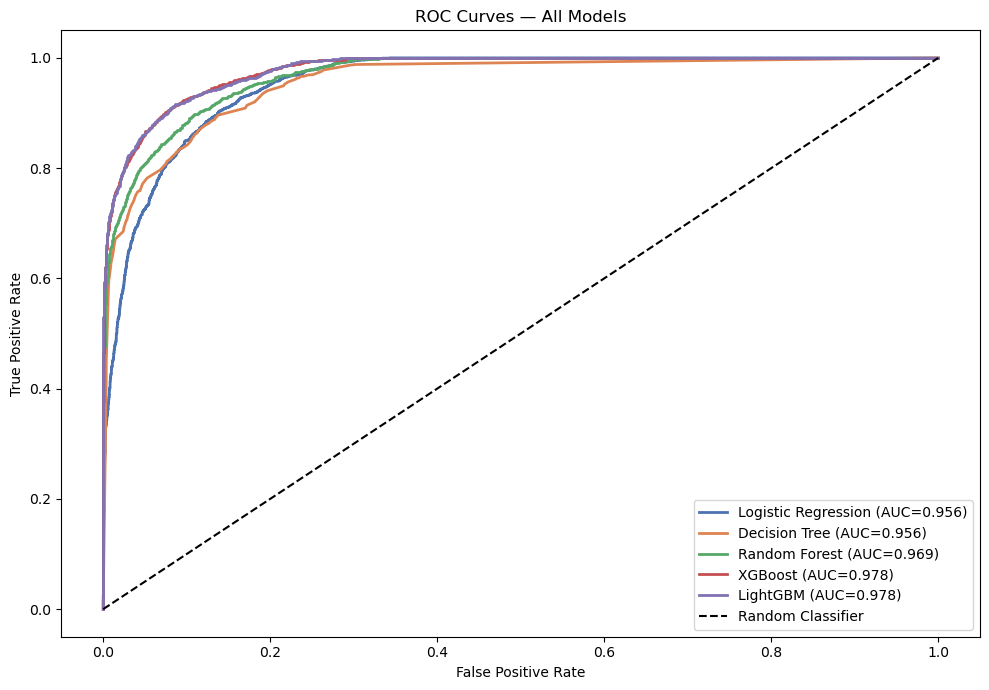

```python
from sklearn.metrics import roc_curve, roc_auc_score

models_proba = {
    "Logistic Regression": (lr,   X_test_scaled),
    "Decision Tree":       (dt,   X_test_scaled),
    "Random Forest":       (rf,   X_test_scaled),
    "XGBoost":             (xgb2, X_test_scaled),
    "LightGBM":            (lgbm, X_test_scaled),
}

colors = ["#4C72B0", "#DD8452", "#55A868", "#C44E52", "#8172B3"]

plt.figure(figsize=(10, 7))

for (name, (model, X)), color in zip(models_proba.items(), colors):
    y_proba = model.predict_proba(X)[:, 1]
    fpr, tpr, _ = roc_curve(y_test, y_proba)
    auc = roc_auc_score(y_test, y_proba)
    plt.plot(fpr, tpr, lw=2, color=color, label=f"{name} (AUC={auc:.3f})")

plt.plot([0, 1], [0, 1], "k--", lw=1.5, label="Random Classifier")
plt.title("ROC Curves — All Models")
plt.xlabel("False Positive Rate")
plt.ylabel("True Positive Rate")
plt.legend(loc="lower right")
plt.tight_layout()
plt.show()
```

### 5.2 Feature Importance — All Models

Shows which features most influenced approval decisions in each model.

> **LightGBM:** Gain-based importance is used instead of default split-count to correctly reflect actual contribution to prediction accuracy.

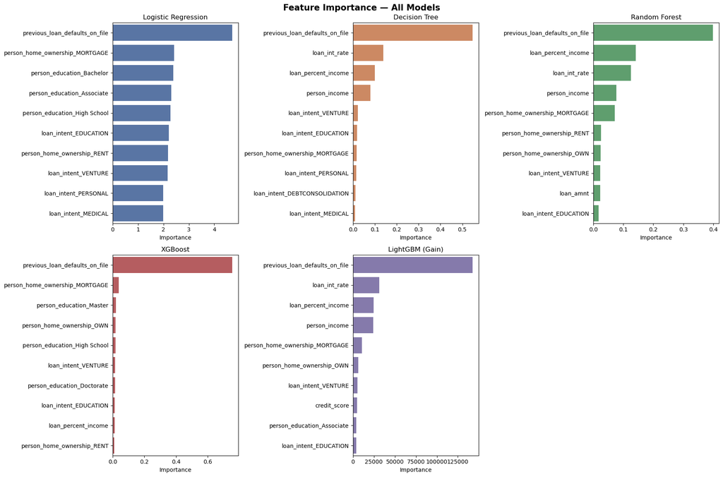

```python
fig, axes = plt.subplots(2, 3, figsize=(18, 12))
fig.suptitle("Feature Importance — All Models", fontsize=15, fontweight="bold")
fig.delaxes(axes[1, 2])

feature_names = X_train.columns

models_fi = {
    "Logistic Regression": abs(lr.coef_[0]),
    "Decision Tree":       dt.feature_importances_,
    "Random Forest":       rf.feature_importances_,
    "XGBoost":             xgb2.feature_importances_,
    "LightGBM (Gain)":     lgbm.booster_.feature_importance(importance_type="gain")
}

colors = ["#4C72B0", "#DD8452", "#55A868", "#C44E52", "#8172B3"]

for (name, importance), ax, color in zip(models_fi.items(), axes.flatten(), colors):
    fi = pd.DataFrame({
        "feature":    feature_names,
        "importance": importance
    }).nlargest(10, "importance")
    sns.barplot(data=fi, y="feature", x="importance", ax=ax, color=color)
    ax.set(title=name, xlabel="Importance", ylabel="")

plt.tight_layout()
plt.show()
```

### 5.3 Final Model Comparison Table

Summary of all models ranked by key metrics.

| Metric | What it means in loan approval context |
| --- | --- |
| **Train Acc** | Performance on training applications |
| **Test Acc** | Performance on unseen applications |
| **Difference** | Overfitting gap — lower is better |
| **Precision** | Of applications flagged as Approved, how many truly were? |
| **Recall** | Of all truly Approvable applications, how many did we catch? |
| **F1 Score** | Balance of precision and recall — primary evaluation metric |

```python
from sklearn.metrics import precision_score, recall_score, f1_score

models_eval = {
    "Logistic Regression": (y_pred_lr,   y_pred_lr_train),
    "Decision Tree":       (y_pred_dt,   y_pred_dt_train),
    "Random Forest":       (y_pred_rf,   y_pred_rf_train),
    "XGBoost":             (y_pred_xgb2, y_pred_xgb2_train),
    "LightGBM":            (y_pred_lgbm, y_pred_lgbm_train),
}

results = []
for name, (y_pred, y_pred_train) in models_eval.items():
    results.append({
        "Model":      name,
        "Train Acc":  f"{accuracy_score(y_train_res, y_pred_train):.2%}",
        "Test Acc":   f"{accuracy_score(y_test, y_pred):.2%}",
        "Difference": f"{abs(accuracy_score(y_train_res, y_pred_train) - accuracy_score(y_test, y_pred)):.2%}",
        "Precision":  f"{precision_score(y_test, y_pred):.3f}",
        "Recall":     f"{recall_score(y_test, y_pred):.3f}",
        "F1 Score":   f"{f1_score(y_test, y_pred):.3f}"
    })

results_df = pd.DataFrame(results).set_index("Model")
print(results_df.to_string())
```

```
                    Train Acc Test Acc Difference Precision Recall F1 Score
Model
Logistic Regression    91.68%   89.98%      1.70%     0.781  0.763    0.772
Decision Tree          92.43%   90.24%      2.18%     0.772  0.795    0.784
Random Forest          93.76%   91.87%      1.89%     0.823  0.808    0.815
XGBoost                97.79%   93.47%      4.33%     0.879  0.819    0.848
LightGBM               96.70%   93.77%      2.93%     0.891  0.820    0.854
```

### 5.4 Save Best Model

Saving LightGBM (best model) and scaler for deployment.

```python
import joblib

joblib.dump(lgbm,   "loan_model.pkl")
joblib.dump(scaler, "scaler.pkl")
print("✓ Model saved  → loan_model.pkl")
print("✓ Scaler saved → scaler.pkl")
```

```
✓ Model saved  → loan_model.pkl
✓ Scaler saved → scaler.pkl
```

## Summary of Findings

[output not shown]

> **Target Variable Reminder:** `loan_status = 1` (Approved) | `loan_status = 0` (Rejected)